# Predictive Modeling

Hayden Patterson

West Chester University

# 1 Introduction

Online retailers want to know which browsing sessions are likely to end in a purchase. In this analysis, I use data on online shopping sessions to build a logistic regression model that predicts whether a session ends in a purchase. The data is split into training and testing sets. I compare three candidate models using 10-fold cross-validation on the training data, and use ROC curves and the area under the curve (AUC) to assess their global performance. The final model is then evaluated on the held-out test data.

# 2 Data and Variable Descriptions

This online shoppers data set (UCI Machine Learning Repository) includes 12,330 observations with 18 variables, 10 numerical and 8 categorical. Each row is one browsing session on an e-commerce website. The 8 categorical variables include the response, `Revenue`.

The 18 variables are:

1. **Administrative**: Number of account-management pages visited in the session.
2. **Administrative_Duration**: Time spent on administrative pages (seconds).
3. **Informational**: Number of informational pages visited.
4. **Informational_Duration**: Time spent on informational pages (seconds).
5. **ProductRelated**: Number of product pages visited.
6. **ProductRelated_Duration**: Time spent on product pages (seconds).
7. **BounceRates**: Average bounce rate of the pages visited (share of visits that leave after viewing only that page).
8. **ExitRates**: Average exit rate of the pages visited (share of views of a page that were the last in the session).
9. **PageValues**: Average value of the pages visited before a purchase was completed.
10. **SpecialDay**: How close the session date is to a special day (such as Valentine’s Day); a score between 0 and 1.
11. **Month**: Month of the session.
12. **OperatingSystems**: Operating system of the visitor (coded as a number).
13. **Browser**: Browser used by the visitor (coded as a number).
14. **Region**: Region of the visitor (coded as a number).
15. **TrafficType**: How the visitor arrived at the site (coded as a number).
16. **VisitorType**: New visitor, returning visitor, or other.
17. **Weekend**: Whether the session happened on a weekend (TRUE/FALSE).
18. **Revenue**: Whether the session ended in a purchase (TRUE/FALSE). This is the response variable.

## 2.1 Loading the Data and Coding the Response

```r
shoppers = read.csv("https://raw.githubusercontent.com/88haypa-collab/STA321_f26/main/ShopperIntention/online_shoppers_intention2.csv")
shoppers$purchase = factor(ifelse(shoppers$Revenue, "pos", "neg"))
table(shoppers$Revenue, shoppers$purchase)   # check: TRUE lines up with pos
```

```
          neg   pos
  FALSE 10422     0
  TRUE      0  1908
```

The data has 12,330 sessions and no missing values. 10,422 sessions ended without a purchase and 1,908 ended in a purchase, about 15.5%, so the response is imbalanced.

# 3 Research Question

The objective of this study is to build a logistic regression model that predicts whether an online shopping session ends in a purchase, using the browsing, visitor, and timing characteristics of the session. I compare several candidate models and select the one with the best predictive performance on unseen data. The data has 12,330 sessions and no missing values. 10,422 sessions ended without a purchase and 1,908 ended in a purchase, about 15.5%, so the response is imbalanced.

# 4 Exploratory Analysis

We first make the following pairwise scatter plots to inspect the potential issues with predictor variables.

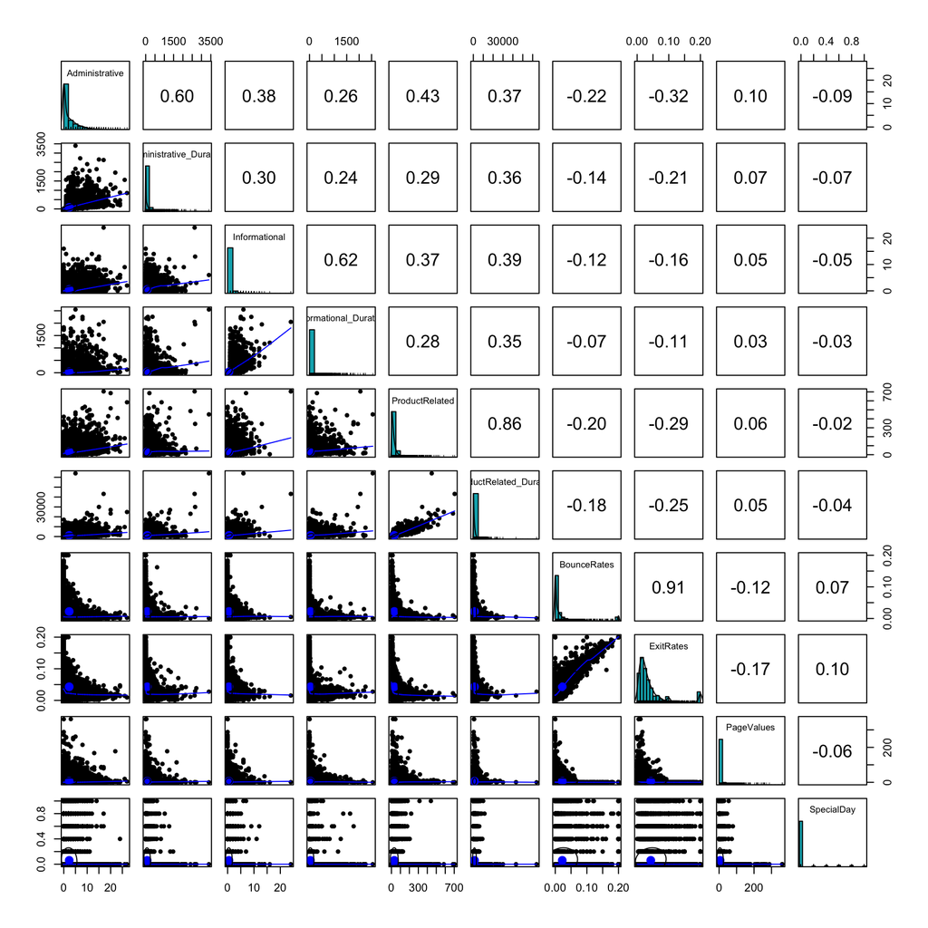

```r
library(psych)
pairs.panels(shoppers[, 1:10],
             method = "pearson",
             hist.col = "#00AFBB",
             density = TRUE,
             ellipses = TRUE
             )
```

```r
detach("package:psych", unload = TRUE)
```

Almost every numeric variable is strongly right-skewed, with a large pile of sessions at 0 and a long right tail. Two pairs are highly correlated: `BounceRates` and `ExitRates` (r = 0.91), and `ProductRelated` and `ProductRelated_Duration` (r = 0.86). Including both variables in either pair could make the coefficient estimates unstable, so I keep `ExitRates` and `ProductRelated` and drop the other two. I also use the page counts `Administrative` and `Informational` and leave out their duration variables, which are correlated with them.

## 4.1 Categorical Variables

Four variables are stored as numbers or text but are categories, so I convert them to factors. Otherwise R would fit a single slope across codes such as `TrafficType` = 1, 2, 3, which has no meaning. `OperatingSystems`, `Browser`, and `Region` are excluded from the models because they describe the visitor’s technical setup and location, not browsing behavior, and `Region` shows little variation in purchase rate.

```r
cat.vars = c("Month", "TrafficType", "VisitorType", "Weekend")
for (v in cat.vars) {
  shoppers[[v]] = factor(shoppers[[v]])
}
str(shoppers[, cat.vars])
```

```
'data.frame':   12330 obs. of  4 variables:
 $ Month      : Factor w/ 10 levels "Aug","Dec","Feb",..: 3 3 3 3 3 3 3 3 3 3 ...
 $ TrafficType: Factor w/ 20 levels "1","2","3","4",..: 1 2 3 4 4 3 3 5 3 2 ...
 $ VisitorType: Factor w/ 3 levels "New_Visitor",..: 3 3 3 3 3 3 3 3 3 3 ...
 $ Weekend    : Factor w/ 2 levels "FALSE","TRUE": 1 1 1 1 2 1 1 2 1 1 ...
```

## 4.2 Discretizing Zero-Heavy Variables

Several of the numeric variables are mostly zeros. The following shows the share of sessions equal to zero for each of the 10 numeric variables.

```r
round(colMeans(shoppers[, 1:10] == 0), 3)
```

```
         Administrative Administrative_Duration           Informational
                  0.468                   0.479                   0.787
 Informational_Duration          ProductRelated ProductRelated_Duration
                  0.805                   0.003                   0.061
            BounceRates               ExitRates              PageValues
                  0.448                   0.006                   0.779
             SpecialDay
                  0.899
```

Four variables are mostly zeros: `SpecialDay` (89.9%), `Informational_Duration` (80.5%), `Informational` (78.7%), and `PageValues` (77.9%). For these, whether the value is zero or positive carries most of the information, so I discretize them into zero/positive indicators. `Administrative` is also about 47% zeros, but it has a wide range of positive values (up to 27 pages), so I keep it as a count and standardize it. `ProductRelated` and `ExitRates` have almost no zeros and stay continuous.

```r
# zero vs. positive page value (Zero is the baseline)
shoppers$PageValues.grp = factor(ifelse(shoppers$PageValues > 0, "Positive", "Zero"),
                                 levels = c("Zero", "Positive"))
# any informational pages vs. none
shoppers$Info.grp = factor(ifelse(shoppers$Informational > 0, "Any", "None"),
                           levels = c("None", "Any"))
# near a special day vs. not
shoppers$Special.grp = factor(ifelse(shoppers$SpecialDay > 0, "Near", "Not near"),
                              levels = c("Not near", "Near"))
round(prop.table(table(shoppers$PageValues.grp, shoppers$Revenue), 1), 3)
```

```
           FALSE  TRUE
  Zero     0.961 0.039
  Positive 0.437 0.563
```

Sessions with zero page value purchase only about 3.9% of the time, compared with about 56.3% for sessions with positive page value, so this indicator separates purchasers from non-purchasers well. Page value is calculated from the pages visited before a purchase, so a strong association is partly built into the variable.

## 4.3 Grouping Sparse Traffic Types

`TrafficType` has 20 levels, and several have very few sessions. I merge the levels with fewer than 50 sessions into an “Other” group, using session counts to decide the grouping.

```r
cutoff = 50
tt = shoppers$TrafficType
tt.counts = table(tt)
sparse = names(tt.counts)[tt.counts < cutoff]
levels(tt)[levels(tt) %in% sparse] = "Other"
shoppers$Traffic.grp = tt
table(shoppers$Traffic.grp)
```

```
    1     2     3     4     5     6 Other     8    10    11    13    20
 2451  3913  2052  1069   260   444   165   343   450   247   738   198
```

After combining the sparse levels, `Traffic.grp` has 12 levels and every group has at least 165 sessions.

# 5 Standardizing Numerical Predictor Variables

Since this is a predictive model, the interpretation of individual coefficients is not the focus. The objective is to identify the model with the best predictive performance. I standardize the three numerical predictors that remain continuous after the discretization step: `ExitRates`, `ProductRelated`, and `Administrative`.

```r
shoppers$sd.exit    = (shoppers$ExitRates - mean(shoppers$ExitRates)) / sd(shoppers$ExitRates)
shoppers$sd.product = (shoppers$ProductRelated - mean(shoppers$ProductRelated)) / sd(shoppers$ProductRelated)
shoppers$sd.admin   = (shoppers$Administrative - mean(shoppers$Administrative)) / sd(shoppers$Administrative)
```

After standardizing, I keep only the response and the variables used in the models. This is the final analytic data set.

```r
sd.shoppers = shoppers[, c("purchase", "sd.exit", "sd.product", "sd.admin",
                           "Info.grp", "PageValues.grp", "Special.grp",
                           "Month", "Weekend", "VisitorType", "Traffic.grp")]
str(sd.shoppers)
```

```
'data.frame':   12330 obs. of  11 variables:
 $ purchase      : Factor w/ 2 levels "neg","pos": 1 1 1 1 1 1 1 1 1 1 ...
 $ sd.exit       : num  3.229 1.171 3.229 1.995 0.143 ...
 $ sd.product    : num  -0.691 -0.668 -0.691 -0.668 -0.489 ...
 $ sd.admin      : num  -0.697 -0.697 -0.697 -0.697 -0.697 ...
 $ Info.grp      : Factor w/ 2 levels "None","Any": 1 1 1 1 1 1 1 1 1 1 ...
 $ PageValues.grp: Factor w/ 2 levels "Zero","Positive": 1 1 1 1 1 1 1 1 1 1 ...
 $ Special.grp   : Factor w/ 2 levels "Not near","Near": 1 1 1 1 1 1 2 1 2 2 ...
 $ Month         : Factor w/ 10 levels "Aug","Dec","Feb",..: 3 3 3 3 3 3 3 3 3 3 ...
 $ Weekend       : Factor w/ 2 levels "FALSE","TRUE": 1 1 1 1 2 1 1 2 1 1 ...
 $ VisitorType   : Factor w/ 3 levels "New_Visitor",..: 3 3 3 3 3 3 3 3 3 3 ...
 $ Traffic.grp   : Factor w/ 12 levels "1","2","3","4",..: 1 2 3 4 4 3 3 5 3 2 ...
```

# 6 Data Split

We randomly split the data into two subsets. 75% of the data will be used as training data. We will use the training data to search the candidate models, validate them and identify the final model using the cross-validation method. The 25% of the hold-up sample will be used for assessing the performance of the final model.

```r
## splitting data: 75% training and 25% testing
set.seed(321)
n <- dim(sd.shoppers)[1]
train.n <- round(0.75*n)
train.id <- sample(1:n, train.n, replace = FALSE)
## training and testing data sets
train <- sd.shoppers[train.id, ]
test <- sd.shoppers[-train.id, ]
## check that the purchase rate is similar in both sets
round(c(train = mean(train$purchase == "pos"), test = mean(test$purchase == "pos")), 3)
```

```
train  test
0.155 0.154
```

After splitting the data into two subsets, the purchase rates are nearly identical (15.5% in the training set and 15.4% in the test set), so the split is well balanced.

# 7 Best Model Identification

I use three candidate models: a full model that contains all of the predictors, a reduced model that contains only exit rate, product-related pages, and visitor type, and the model obtained by forward selection (based on AIC) from the reduced model up to the full model. All three are fit using the training data only.

For illustration, I use 0.5 as the common cut-off probability for all three models to define the predicted outcome. In a real application, we may want to find the optimal cut-off for each candidate model in the cross-validation process. This is especially relevant here because only about 15.5% of sessions end in a purchase.

```r
library(MASS)

## full model
candidate01 = glm(purchase ~ ., family = binomial(link = "logit"), data = train)

## reduced model
candidate03 = glm(purchase ~ sd.exit + sd.product + VisitorType,
                  family = binomial(link = "logit"), data = train)

## forward selection from the reduced model up to the full model
candidate02 = stepAIC(candidate03,
                      scope = list(lower = formula(candidate03), upper = formula(candidate01)),
                      direction = "forward", trace = 0)
formula(candidate02)
```

```
purchase ~ sd.exit + sd.product + VisitorType + PageValues.grp +
    Month + sd.admin + Traffic.grp
```

## 7.1 Cross-Validation for Model Identification

```r
## 10-fold cross-validation
set.seed(321)
k = 10
## floor() function must be used to avoid producing NA in the subsequent results
fold.size = floor(dim(train)[1]/k)
## PE vectors for candidate models
PE1 = rep(0, k)
PE2 = rep(0, k)
PE3 = rep(0, k)
for (i in 1:k) {
  ## Training and validation folds
  valid.id = (fold.size*(i-1)+1):(fold.size*i)
  valid = train[valid.id, ]
  train.dat = train[-valid.id, ]
  ## full model
  cv.m1 = glm(purchase ~ .,
              family = binomial(link = "logit"),
              data = train.dat)
  ## reduced model
  cv.m3 = glm(purchase ~ sd.exit + sd.product + VisitorType,
              family = binomial(link = "logit"),
              data = train.dat)
  ## forward selection from the reduced model
  cv.m2 = stepAIC(cv.m3,
                  scope = list(lower = formula(cv.m3), upper = formula(cv.m1)),
                  direction = "forward",
                  trace = 0)
  ## predicted probabilities of each candidate model
  pred1 = predict(cv.m1, newdata = valid, type = "response")
  pred2 = predict(cv.m2, newdata = valid, type = "response")
  pred3 = predict(cv.m3, newdata = valid, type = "response")

  pre.outcome1 = ifelse(pred1 > 0.5, "pos", "neg")
  pre.outcome2 = ifelse(pred2 > 0.5, "pos", "neg")
  pre.outcome3 = ifelse(pred3 > 0.5, "pos", "neg")

  PE1[i] = 1 - sum(pre.outcome1 == as.vector(valid$purchase))/length(pred1)
  PE2[i] = 1 - sum(pre.outcome2 == as.vector(valid$purchase))/length(pred2)
  PE3[i] = 1 - sum(pre.outcome3 == as.vector(valid$purchase))/length(pred3)
}
avg.pe = cbind(PE.1 = mean(PE1), PE.2 = mean(PE2), PE.3 = mean(PE3))
pander(avg.pe, caption = "Average of prediction errors of candidate models")
```

Average of prediction errors of candidate models The average prediction errors show that candidate models 1 and 2 have nearly the same predictive error (0.106), while the reduced model (0.155) does no better than always predicting “no purchase”, which would have an error of about 0.155 given the 15.5% purchase rate. Since model 2 is simpler than model 1, I choose model 2 as the final predictive model. This selection is based on the cut-off probability 0.5.

| PE.1 | PE.2 | PE.3 |
| --- | --- | --- |
| 0.1058 | 0.1062 | 0.1554 |

## 7.2 Final Model Reporting

```r
pred02 = predict(candidate02, newdata = test, type = "response")
pred02.outcome = ifelse(as.vector(pred02) > 0.5, "pos", "neg")

accuracy = sum(pred02.outcome == test$purchase)/length(pred02)
pander(accuracy, caption = "The actual accuracy of the final model")
```

*0.8952*

```r
## confusion matrix, sensitivity, and specificity at the 0.5 cut-off
cm = table(Predicted = pred02.outcome, Actual = test$purchase)
cm
```

```
         Actual
Predicted  neg  pos
      neg 2474  191
      pos  132  285
```

```r
sensitivity = cm["pos", "pos"] / (cm["pos", "pos"] + cm["neg", "pos"])
specificity = cm["neg", "neg"] / (cm["neg", "neg"] + cm["pos", "neg"])
c(sensitivity = sensitivity, specificity = specificity)
```

```
sensitivity specificity
  0.5987395   0.9493477
```

The actual accuracy of the final model on the test data is 89.5%. Because only about 15.5% of sessions end in a purchase, always predicting “no purchase” would already be correct about 84.6% of the time, so accuracy alone overstates the model’s value. At the 0.5 cut-off, the model has a specificity of 94.9% but a sensitivity of only 59.9%, so it misses about 40% of the sessions that end in a purchase. The 0.5 cut-off may not be the best choice for this imbalanced data, which motivates the ROC analysis in the next section.

# 8 ROC Analysis - Global Performance

The ROC curve as a visual tool is used to compare the global performance of binary predictive models. Since it is used for the purpose of model selection, we need to construct ROC curves based on the training data. Next, we will construct ROC curves and calculate the corresponding AUCs using package pROC.

We first estimate the TPR (true positive rate, sensitivity) and FPR (false positive rate, 1 - specificity) at each cut-off probability for each of the three candidate models using the following R function.

```r
## A function to extract true positive and false positive rates
TPR.FPR = function(pred){
  prob.seq = seq(0, 1, length = 50)  # 50 equally spaced cut-off probabilities
  pn = length(prob.seq)
  true.lab = as.vector(train$purchase)
  TPR = NULL
  FPR = NULL
  ##
  for (i in 1:pn){
   pred.lab = as.vector(ifelse(pred > prob.seq[i], "pos", "neg"))
   TPR[i] = length(which(true.lab == "pos" & pred.lab == "pos"))/length(which(true.lab == "pos"))
   FPR[i] = length(which(true.lab == "neg" & pred.lab == "pos"))/length(which(true.lab == "neg"))
  }
 cbind(FPR = FPR, TPR = TPR)
}
```

The ROC curves of the three candidate models are given below.

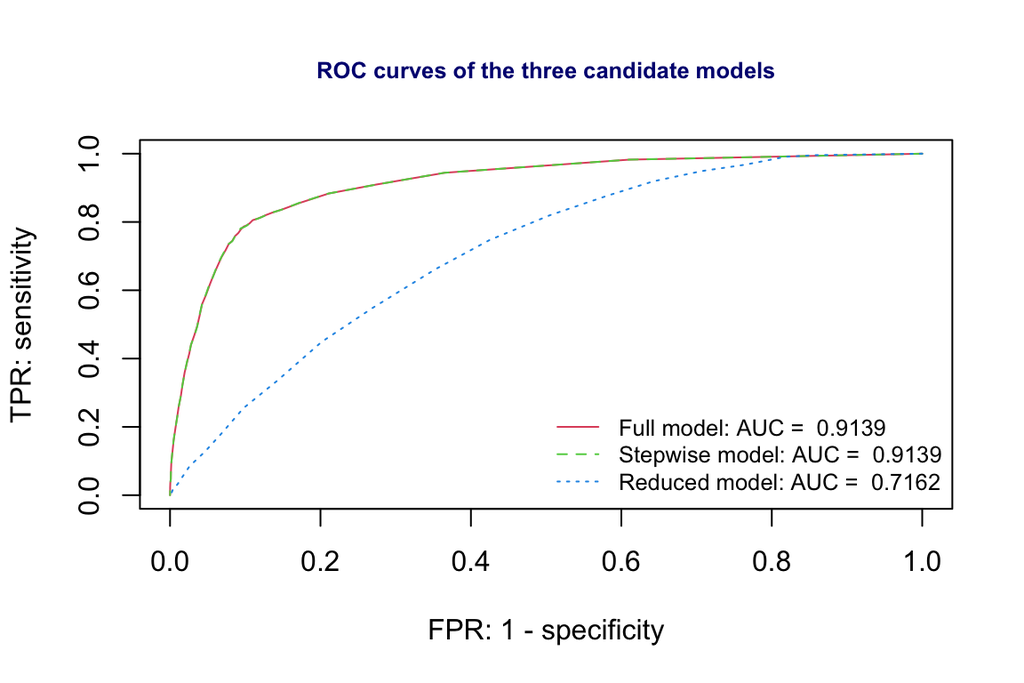

```r
if (!require("pROC")) {
   install.packages("pROC")
   library(pROC)
}
## predicted probabilities on the training data
pred01 = predict.glm(candidate01, newdata = train, type = "response")
pred02 = predict.glm(candidate02, newdata = train, type = "response")
pred03 = predict.glm(candidate03, newdata = train, type = "response")
####
## ROC curves
plot(TPR.FPR(pred01)[,1], TPR.FPR(pred01)[,2],
     type = "l", col = 2, lty = 1, xlim = c(0,1), ylim = c(0,1),
     xlab = "FPR: 1 - specificity",
     ylab = "TPR: sensitivity",
     main = "ROC curves of the three candidate models",
     cex.main = 0.8,
     col.main = "navy")
lines(TPR.FPR(pred02)[,1], TPR.FPR(pred02)[,2], col = 3, lty = 2)
lines(TPR.FPR(pred03)[,1], TPR.FPR(pred03)[,2], col = 4, lty = 3)

category = train$purchase == "pos"
ROCobj01 <- roc(category, as.vector(pred01))
ROCobj02 <- roc(category, as.vector(pred02))
ROCobj03 <- roc(category, as.vector(pred03))
AUC01 = round(auc(ROCobj01), 4)
AUC02 = round(auc(ROCobj02), 4)
AUC03 = round(auc(ROCobj03), 4)
##
legend("bottomright", c(paste("Full model: AUC = ", AUC01),
                        paste("Stepwise model: AUC = ", AUC02),
                        paste("Reduced model: AUC = ", AUC03)),
       col = 2:4, lty = 1:3, cex = 0.8, bty = "n")
```

The ROC curves of the full model and the stepwise model are almost identical, and both have an AUC of 0.9139. The reduced model is clearly worse, with an AUC of 0.7162, which shows that exit rate, product pages, and visitor type alone carry much less information than the full set of predictors. Since the stepwise model performs the same as the full model with fewer variables, the final model is the stepwise model. This agrees with the cross-validation result, so both methods select the same model.

# 9 Summary and Conclusion

This study focused on predicting whether an online shopping session ends in a purchase. I used three candidate models: a full model, a reduced model, and a model obtained by forward selection from the reduced model. I used both cross-validation and ROC curves to select the final working model. Ten-fold cross-validation on the training data gave nearly identical prediction errors for the full and stepwise models (about 0.106), while the reduced model (0.155) did no better than always predicting “no purchase.” The ROC curves gave the same result: the full and stepwise models both had an AUC of 0.9139, compared with 0.7162 for the reduced model. Since the stepwise model is simpler, it was selected as the final model.

On the held-out test data, the final model has an accuracy of 89.5%, compared with about 84.6% for always predicting “no purchase.” At the 0.5 cut-off, its specificity is 94.9% but its sensitivity is only 59.9%, so it misses about 40% of the sessions that end in a purchase. The ROC curve shows that a lower cut-off could raise sensitivity considerably for a modest increase in false alarms, so choosing the cut-off based on the costs of each type of error would be a natural next step.

There are some limitations. The page-value indicator is calculated from the pages visited before a purchase, so part of its predictive power is built into the variable, and it would not be available for predicting a session that is still in progress. The means and standard deviations used for standardizing were computed from the full data before the split. Sparse categories, such as February and the “Other” visitor type, give unstable estimates.